# STAT 501 Homework 2

Steve Harms

February 8, 2019

First, I make a few functions to make the data generation and estimation easy, and test them. The results of the simulation are at the bottom.

```r
library(MASS)
library(tidyverse)
library(kableExtra)

#generate covariates
covariategen <- function(n,p){
  mvnSig <- matrix(0,ncol=p,nrow=p)
  i=0
  repeat{
    i=i+1
    j=0
    repeat{
      j=j+1
      mvnSig[i,j] <- 0.75^(abs(i-j))
      if(j==p){break}
    }
    if(i==p){break}
  }
    covmat <- mvrnorm(n=n, mu=rep(0,times=p), Sigma = mvnSig)
    Betas <- rep(c(1,0), each=p/2)
    return(list(xis = covmat, B=Betas))
}

errorgen <- function(n, dist, df=0){
  eis <- rnorm(n=n, mean=0, sd=1)
  if(dist=="t"){
    eis = rt(n=n, df=df, ncp=0)
    eis = eis/sd(eis)
  }
  if(dist=="exponential"){
    eis = rexp(n=n, rate=1)
    eis = eis-mean(eis)
  }
  return(eis)
}

simulator <- function(n,p, dist, dof,reps){
        estimates <- matrix(nrow=reps,ncol=p)
        cicovs <- matrix(nrow=reps,ncol=p)
  i=0
  repeat{
    i=i+1
  #generate data
  covs <- covariategen(n,p)
  xis <- covs$xis
  Betas <- covs$B
  errors <- errorgen(n, dist=dist, df=dof)
  yis <- xis%*%Betas + errors
  #estimate
  lm.temp <- lm(formula=yis~xis)
  estimates[i,] <- coef(lm.temp)[-1]
  cis <- confint(lm.temp, level=0.95)
  cicovs[i,] <- c(cis[-1,1] <= Betas & Betas <= cis[-1,2])
  if(i==reps){break}
  }
  return(list(ests=estimates, CIcovs = cicovs))
}


#PUT ALL OBS IN A LIST
listify<- function(nlist,distlist,dflist,reps,p){
  estarray <- array(dim=c(length(nlist), length(distlist), reps, p))
  ciarray <- estarray
  nc=0
  repeat{
    nc=nc+1
      dc = 0
      repeat{
        dc=dc+1
        n=nlist[nc];  distf = distlist[dc]; ddf=dflist[dc]
        sims <- simulator(n=n, p=p, dist=distf, dof=ddf, reps = reps)
        estarray[nc,dc,,] <- sims$ests
        ciarray[nc,dc,,] <- sims$CIcovs
        if(dc==length(distlist)){break}
    }
    if(nc==length(nlist)){break}
  }
  return(list(CIs = ciarray, ests=estarray))
}
```

**First let’s test our covariate data generating function to make sure it’s generating correctly:**

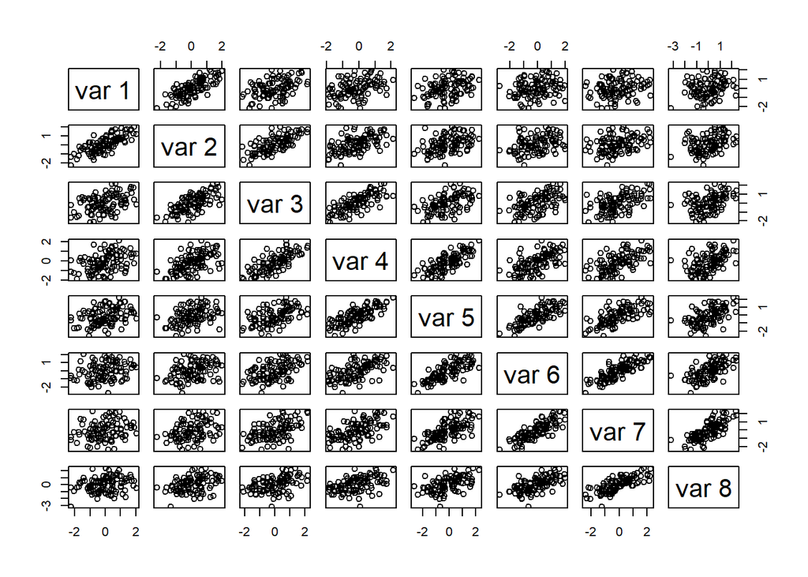

```r
covariategen(n=100,p=8)$xis %>% pairs
```

**Next, we test our error term function:**

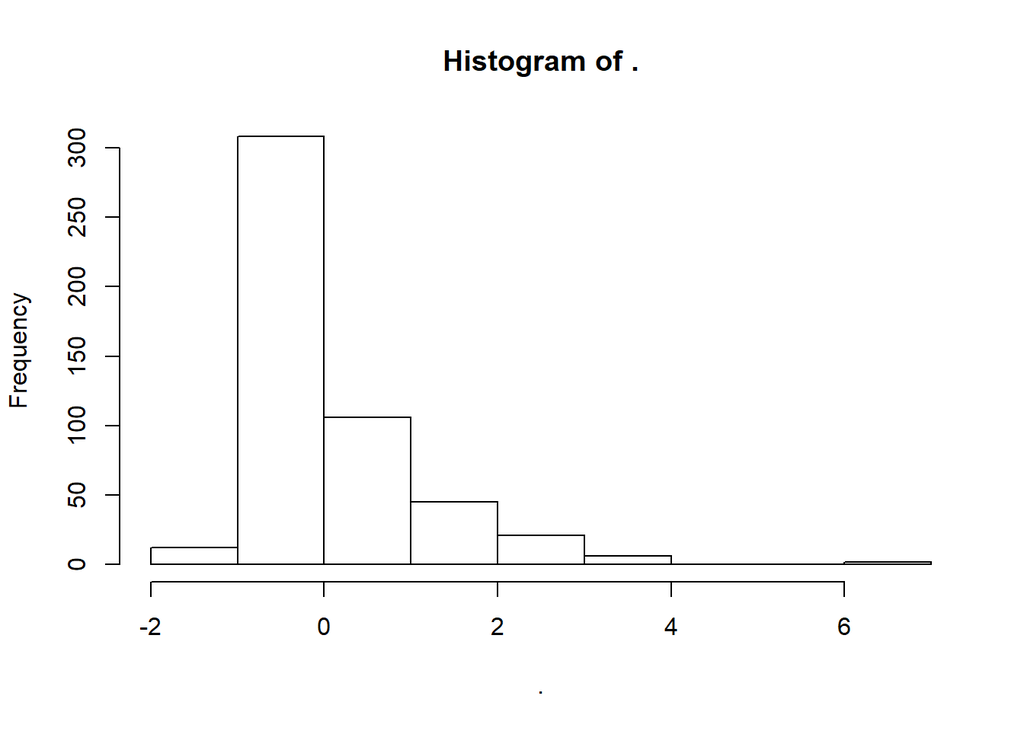

```r
errorgen(n=500,dist="exponential") %>% hist()
```

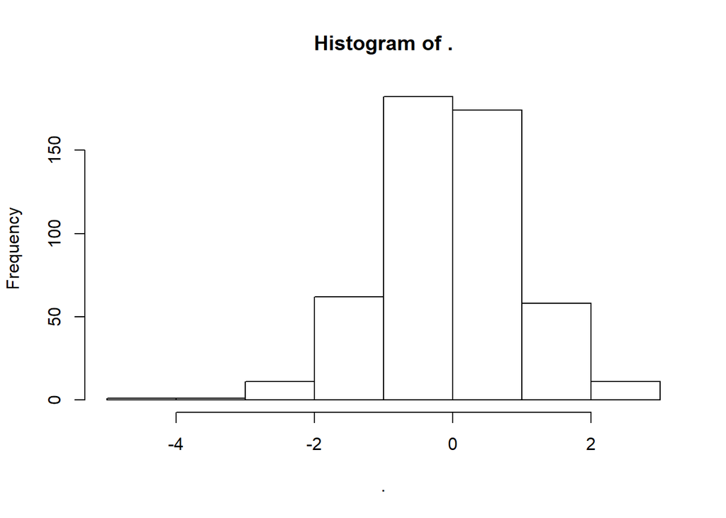

```r
errorgen(n=500, dist="t", df=10) %>% hist()
```

**It looks like the covariates and errors are being generated correctly.**

**Now, we can simulate all of the 16 combinations we want to study in one command:**

```r
nlist <- c(40, 80)
plist <- c(10, 30)
errordistlist <- c("normal", "t","t", "exponential")
dflist <- c(0,3,10,1)
set.seed(112358)

smallp <- listify(nlist=nlist,distlist=errordistlist,dflist=dflist,reps=1000,p=10)
largep <- listify(nlist=nlist,distlist=errordistlist,dflist=dflist,reps=1000,p=30)

colnames(smallp$CIs) <- colnames(smallp$ests) <- colnames(largep$ests) <-colnames(largep$CIs) <- paste(errordistlist, c("", "3","10",""))
rownames(smallp$CIs) <- rownames(smallp$ests) <- rownames(largep$ests) <-rownames(largep$CIs) <- c("n=40", "n=80")
```

Finally, summarize the data and put it into some tables:

```r
#summarize the data
#this could be done much more efficiently but it's the same result
p9 <- smallp$CIs %>% apply(c(1,2,4),mean) %>% apply(c(1,2), mean) %>% t
p10 <- smallp$ests %>% apply(c(1,2,4),mean) %>% apply(c(1,2), mean) %>% t
p1 <- smallp$CIs[,,,1:5]%>% apply(c(1,2,4),mean) %>% apply(c(1,2), mean) %>% t
p2 <-smallp$ests[,,,1:5]%>% apply(c(1,2,4),mean) %>% apply(c(1,2), mean) %>% t
p3 <- smallp$CIs[,,,6:10]%>% apply(c(1,2,4),mean) %>% apply(c(1,2), mean) %>% t
p4 <- smallp$ests[,,,6:10]%>% apply(c(1,2,4),mean) %>% apply(c(1,2), mean) %>% t
p11 <- largep$CIs %>% apply(c(1,2,4),mean) %>% apply(c(1,2), mean) %>% t
p12 <- largep$ests %>% apply(c(1,2,4),mean) %>% apply(c(1,2), mean) %>% t
p5<- largep$CIs[,,,1:15]%>% apply(c(1,2,4),mean) %>% apply(c(1,2), mean) %>% t
p6<-largep$ests[,,,1:15]%>% apply(c(1,2,4),mean) %>% apply(c(1,2), mean) %>% t
p7<- largep$CIs[,,,16:30]%>% apply(c(1,2,4),mean) %>% apply(c(1,2), mean) %>% t
p8<-largep$ests[,,,16:30]%>% apply(c(1,2,4),mean) %>% apply(c(1,2), mean) %>% t
resultsp10 <-cbind(p2,p1,p4,p3,p10,p9)[,c(seq(1,11,by=2),seq(2,12,by=2))]
resultsp30 <-cbind(p6,p5,p8,p7,p12,p11)[,c(seq(1,11,by=2),seq(2,12,by=2))]
colnames(resultsp10) <- colnames(resultsp30) <- rep(c("Est", "CIcovg"),times=6)

resultsp10 %>% round(4) %>% kable(caption="p=10") %>%  kable_styling(c("striped", "bordered")) %>%
  add_header_above(c(" ", "B=1" = 2, "B=0" = 2, "All B" = 2, "B=1" = 2, "B=0" = 2, "All B" = 2)) %>%
  add_header_above(c(" ", "n=40"=6, "n=80"=6))
```

p=10

|  | n=40 B=1 Est | n=40 B=1 CIcovg | n=40 B=0 Est | n=40 B=0 CIcovg | n=40 All B Est | n=40 All B CIcovg | n=80 B=1 Est | n=80 B=1 CIcovg | n=80 B=0 Est | n=80 B=0 CIcovg | n=80 All B Est | n=80 All B CIcovg |
| --- | --- | --- | --- | --- | --- | --- | --- | --- | --- | --- | --- | --- |
| normal | 0.9988 | 0.9518 | 0.0000 | 0.9496 | 0.4994 | 0.9507 | 1.0001 | 0.9548 | -0.0002 | 0.9506 | 0.4999 | 0.9527 |
| t 3 | 1.0013 | 0.9520 | -0.0018 | 0.9522 | 0.4997 | 0.9521 | 0.9999 | 0.9452 | -0.0003 | 0.9474 | 0.4998 | 0.9463 |
| t 10 | 0.9991 | 0.9502 | -0.0006 | 0.9496 | 0.4993 | 0.9499 | 0.9979 | 0.9468 | 0.0011 | 0.9526 | 0.4995 | 0.9497 |
| exponential | 0.9989 | 0.9548 | -0.0003 | 0.9504 | 0.4993 | 0.9526 | 1.0001 | 0.9490 | -0.0011 | 0.9506 | 0.4995 | 0.9498 |

```r
resultsp30 %>% round(4) %>% kable(caption="p=30") %>%  kable_styling(c("striped", "bordered")) %>%
  add_header_above(c(" ", "B=1" = 2, "B=0" = 2, "All B" = 2, "B=1" = 2, "B=0" = 2, "All B" = 2)) %>%
  add_header_above(c(" ", "n=40"=6, "n=80"=6))
```

p=30

|  | n=40 B=1 Est | n=40 B=1 CIcovg | n=40 B=0 Est | n=40 B=0 CIcovg | n=40 All B Est | n=40 All B CIcovg | n=80 B=1 Est | n=80 B=1 CIcovg | n=80 B=0 Est | n=80 B=0 CIcovg | n=80 All B Est | n=80 All B CIcovg |
| --- | --- | --- | --- | --- | --- | --- | --- | --- | --- | --- | --- | --- |
| normal | 0.9983 | 0.9441 | -0.0006 | 0.9523 | 0.4988 | 0.9482 | 1.0000 | 0.9468 | -0.0011 | 0.9500 | 0.4994 | 0.9484 |
| t 3 | 0.9988 | 0.9511 | -0.0021 | 0.9497 | 0.4984 | 0.9504 | 0.9991 | 0.9488 | 0.0004 | 0.9522 | 0.4998 | 0.9505 |
| t 10 | 1.0002 | 0.9530 | -0.0001 | 0.9499 | 0.5000 | 0.9514 | 1.0005 | 0.9465 | -0.0003 | 0.9440 | 0.5001 | 0.9452 |
| exponential | 0.9978 | 0.9444 | 0.0008 | 0.9469 | 0.4993 | 0.9456 | 1.0002 | 0.9500 | 0.0003 | 0.9508 | 0.5003 | 0.9504 |

**Now that we have all of our results together, we can answer the questions at hand.**

**1) How does sample size affect the estimates?**

**2) How does dimension affect the estimates?**

Now we compare differences between p=10 and p=30, i.e., across the 2 tables above. Interestingly, there are no noticeable differences in estimation or confidence interval coverage between the two, after controlling for error distribution and sample size. Comparing element-wise between our two tables, there is no noticeable pattern. This is somewhat unexpected because we know the covariates are correlated and thus we should likely see some sort of bias due to autocorrelation. However this is not visible in our data, possibly due to our Monte Carlo sample size of 1000 which allows for nearly asymptotic estimates of the bias.

However, the exponential distribution is not symmetric, so we might expect some irregularities with that distribution. In reality, the empirical coverage is slightly below the nominal rate for the p=30/n=40 with exponential errors. This might support the claim that the normal-theory confidence interval may not be perfect when we know our distribution is skewed, however it is not enough to overturn the asymptotic results.

**In conclusion, there is little or no evidence that the error distribution has a significant impact on the confidence interval coverage for ordinary least squares regression. We can conclude that the inference procedure is quite robust to departures from normality.**